# DP

JcB

01/10/2014

# 1 Analyse des diagnostics principaux

Pour l’analyse, le fichier doit s’appeler dx. Ainsi pour 2014 on mettra dans le préambule dx <- d14.

Avec **stringr** il est possible de faire des recherches de chaines comme si on uilisait des expression régulière. Au préalable, pour supprimer le point comme dans J45.1, on peut utiliser l’expression:

```
a <- "J45.1"
str_replace_all(a, "\\.", "")
```

Pour rechercher une phrase, il faut d’abord définir un pattern: [J][4][56]. La phrase doit commencer par un J, suivi d’un 4 puis d’un 5 ou 6.

```
pattern <- "[J][4][56]"
dx.asthme <- dx$DP[!is.na(dx$DP) & str_detect(dx$DP, pattern) == TRUE]
summary(dx.asthme)
```

On obtient:

```
J45 J450 J451 J458 J459  J46
216  143  243   19 1109   59
```

# 2 Indicateurs InVS

Pour une pathologie donnée, l’InVS calcule le rapport du nombre de cas divisé par le nombre total de diagnostics codés pendant la période ce qui permet de s’affranchir de l’exhaustivité.

# 3 Initialisation

# 4 Combien de sorte de DP sont crées par jour ?

ex. avec Sélestat: on crée un objet de type liste formé d’autant de listes qu’il y a de jours (1 liste par jour). Chaque liste est formée par les codes CIM10 du jour, lesquels ont regroupés par type grace à la méthode table. Au final on obtient pour chaque jour la liste des codes CIM et pour chaque code, le nombre de dossiiers correspondants. Par la fonction *length* on compte le nombre de diagnostics uniques. L’ensemble est résumé par la fonction *summary*.

```
[1] 68
```

```
 A083  E139  F063  F480  G458  H664  H669  I269   I64   J00  J060  J159
    1     1     1     1     2     1     1     1     1     1     1     3
 J180  J209   J40   J90  K522  K590  K625  K800  K819  K851  K922  L022
    1     1     1     1     1     2     1     1     2     1     1     1
 L024  L050 M1997 M2546 M7908   N10   N23  P282  Q188  R073  R074  R102
    1     1     1     1     1     1     1     1     1     1     1     1
 R104  R296   R51 R53+0 R53+1  S004  S013  S018  S060  S202 S4220 S4240
    2     1     1     1     1     1     1     2     1     2     1     1
 S435  S501  S520  S602  S610  S628 S7200  S800  S810  S834 S9220  S934
    1     1     1     1     2     1     1     1     1     1     1     1
 S936 T0230  T200  T438  T519  T754  Z027  Z538
    1     2     1     1     1     1     1     3
```

```
   Min. 1st Qu.  Median    Mean 3rd Qu.    Max.
   1.00   58.00   63.00   62.08   69.00   92.00
```

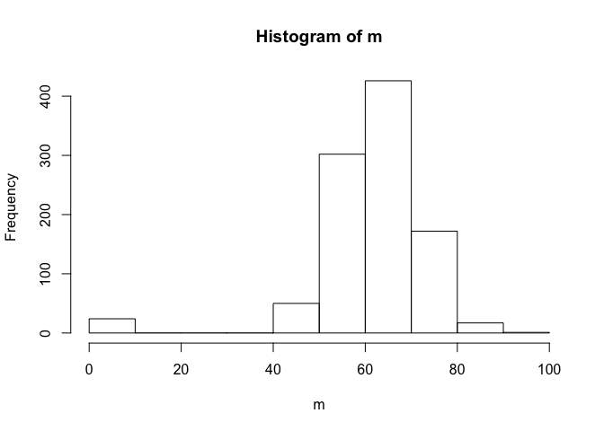

# 5 Bronchiolites

```r
bron<-dpr[substr(dpr$DP,1,3)=="J21" & dpr$AGE < 10 ,] # on limite aux moins de 10 ans
n.bron <- nrow(bron) # nombre de bronchiolites
# age des bronchioloites en mois
age.bron <- (as.Date(bron$ENTREE) - as.Date(bron$NAISSANCE))/30

n2 <- length(age.bron[age.bron < 25]) # nb de 24 mois (2 ans)
round(n2 * 100 / n.bron, 2) # % de 2 ans et moins
```

```
## [1] 96.88
```

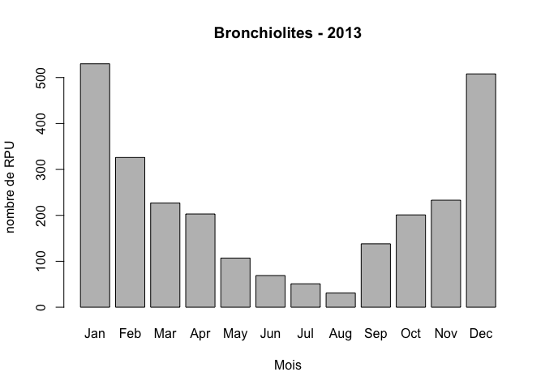

```r
titre <- paste0("Bronchiolites", " - ", anc)

m<-month(bron$ENTREE,label=T)
barplot(table(m),main = titre, xlab="Mois", ylab = "nombre de RPU")
```

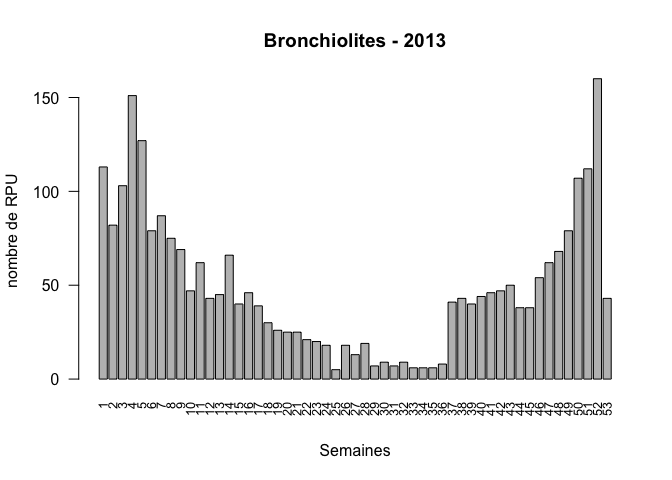

```r
# nombre de bronchiolites par semaine
s<-week(bron$ENTREE)
n.bronchio.par.semaine <- table(s)
barplot(table(s),main = titre, xlab = "Semaines", ylab = "nombre de RPU", las = 2, cex.names = 0.8)
```

```r
# ages des enfants en mois
age.bron <- (as.Date(bron$ENTREE) - as.Date(bron$NAISSANCE))/30
s.age.bron <- summary(as.numeric(age.bron)) # résumé
ceiling(as.numeric(s.age.bron["Min."] * 30)) # age min en jours
```

```
## [1] 7
```

```r
# sexe
summary(bron$SEXE)
```

```
##    F    I    M
## 1005    1 1618    0
```

```r
# age de tous les RPU en jours
age.jours <- as.numeric(as.Date(dx$ENTREE) - as.Date(dx$NAISSANCE))

# age de tous les rpu en mois
age.en.mois <- as.numeric(as.Date(dx$ENTREE) - as.Date(dx$NAISSANCE))/30

# nb de rpu de moins de 24 mois
ped2.age <- age.en.mois[age.en.mois > 0 & age.en.mois < 24.1]
summary(ped2.age)
```

```
##     Min.  1st Qu.   Median     Mean  3rd Qu.     Max.
##  0.03333  4.53300 10.77000 10.98000 17.00000 24.07000
```

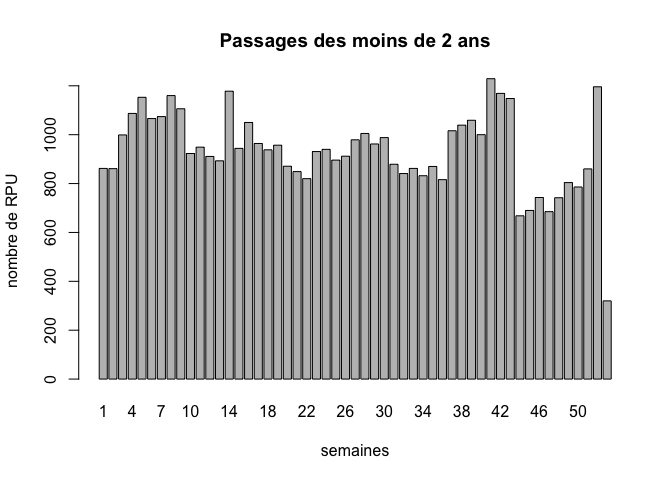

```r
# il faut calculer le nombre de rpu de moins de 2 ans par semaine, puis voir ce que les bronchiolites représentent en %

a <- data.frame(dx$ENTREE, age.en.mois)
a <- a[a$age.en.mois > 0 & a$age.en.mois < 24.1,]
colnames(a) <- c("ENTREE", "AGE.MOIS")


# nombre de passages des moins de 2 ans par semaine
# NB: semaine 41 = nouveau flux des HUS
n.rpu.inf2ans.par.semaine <- tapply(as.Date(a$ENTREE), week(as.Date(a$ENTREE)), length)
barplot(n.rpu.inf2ans.par.semaine, main = "Passages des moins de 2 ans", ylab = "nombre de RPU", xlab = "semaines")
```

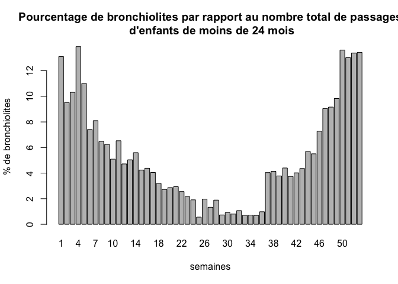

```r
# Pourcentage de bronchiolites par rapport au nombre total de passages d'enfants de moins de 24 mois
a <- round(n.bronchio.par.semaine * 100 / n.rpu.inf2ans.par.semaine, 2)
barplot(a, xlab = "semaines", ylab = "% de bronchiolites", main = "Pourcentage de bronchiolites par rapport au nombre total de passages\n d'enfants de moins de 24 mois")
```

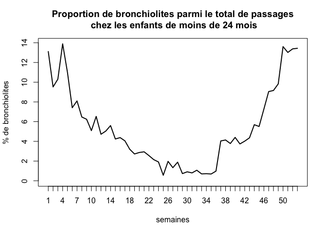

```r
# sous forme de courbe type InVS
plot(a, type="l", xlab = "semaines", ylab = "% de bronchiolites", main = "Proportion de bronchiolites parmi le total de passages\n chez les enfants de moins de 24 mois")
```

# 6 Syndrome grippal

**ATENTION**: les gaphiques de ce paragraphe ne sont exact que **dpr** ne concerne que 2014. La transformation en mois supprime la notion d’année => si plusieurs années, la transformation en mois entraïne la somme des valeurs du mois: par ex. mois 1 correspond à la somme janvier 2014 et janvier 2015.

nombre de cas de grippes diagnostiqués aux urgences:

- 2013: 626
- 2014: 289
- 2015: 1205

## 6.1 Grippes en 2014 et 2015

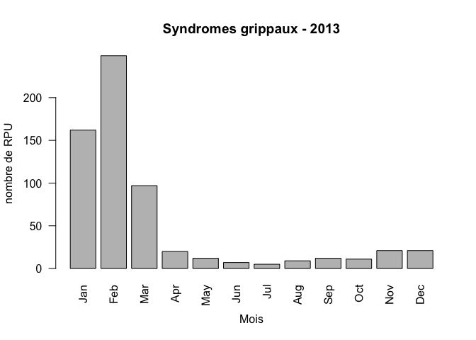

```r
anc <- 2014

titre <- paste0("Syndromes grippaux", " - ", anc-1)
m2013<-month(g2013$ENTREE,label=T)
barplot(table(m2013),main = titre, xlab="Mois", ylab = "nombre de RPU", las = 2)
```

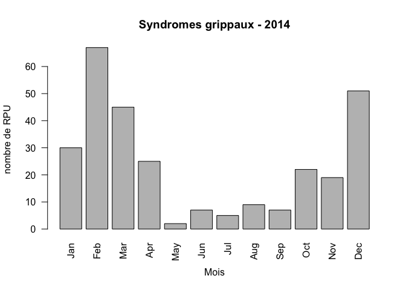

```r
titre <- paste0("Syndromes grippaux", " - ", anc)
m2014<-month(g2014$ENTREE,label=T)
barplot(table(m2014),main = titre, xlab="Mois", ylab = "nombre de RPU", las = 2)
```

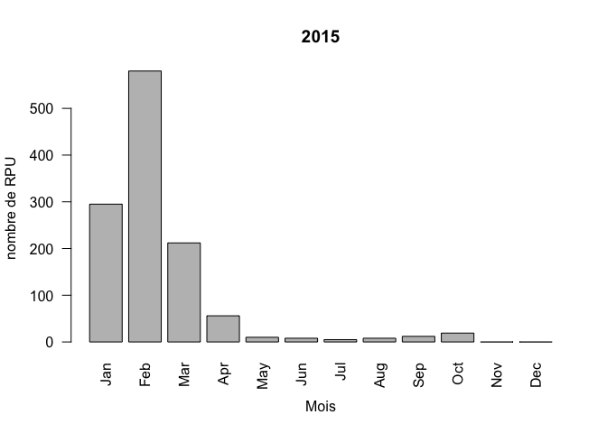

```r
titre <- paste0("Syndromes grippaux", " - ", anc + 1)
m2015<-month(g2015$ENTREE,label=T)
barplot(table(m2015),main = "2015", xlab="Mois", ylab = "nombre de RPU", las = 2)
```

## 6.2 Répartition par age

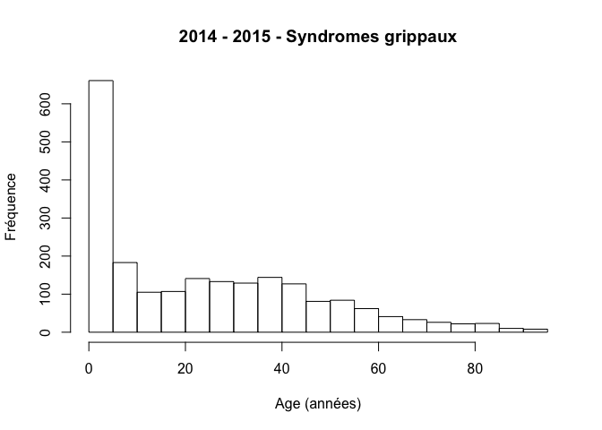

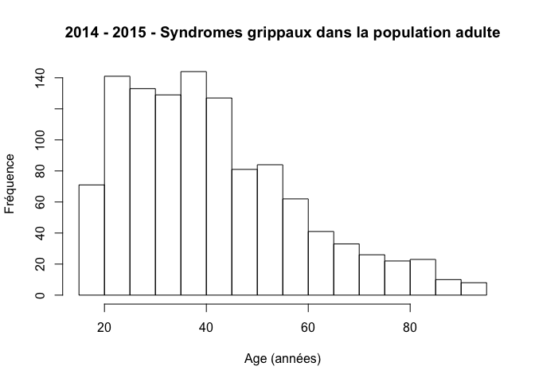

## 6.3 Gravité

```
##
##    1    2    3    4    5    D    P
##  558 1398   87    3    1    1    0    0
```

## 6.4 Comparaison 2014 - 2015

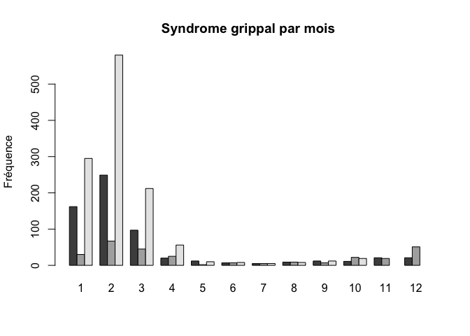

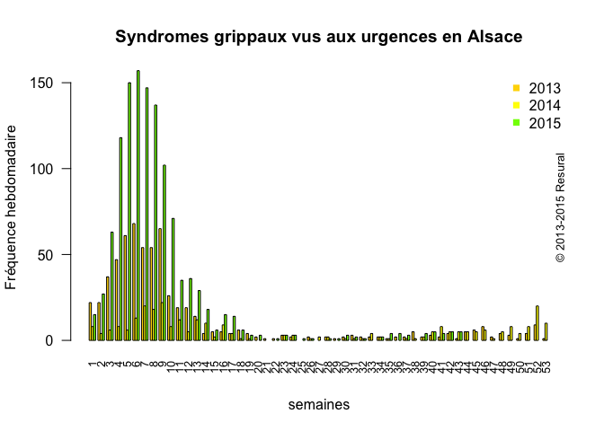

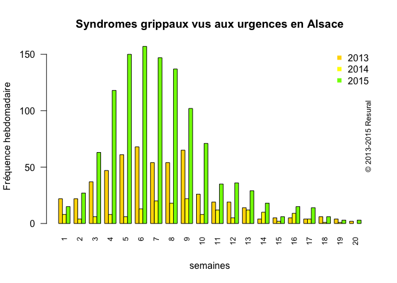

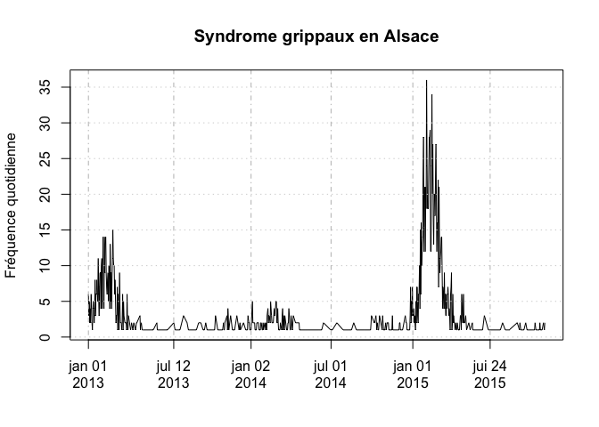

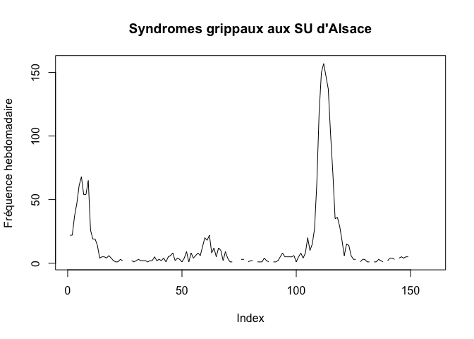

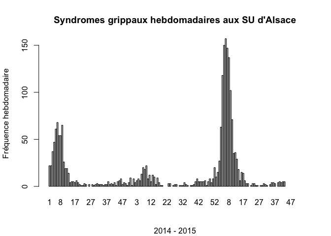

# 7 Allergies respiratoires

- rhinite allergique: J30
- asthme: J45

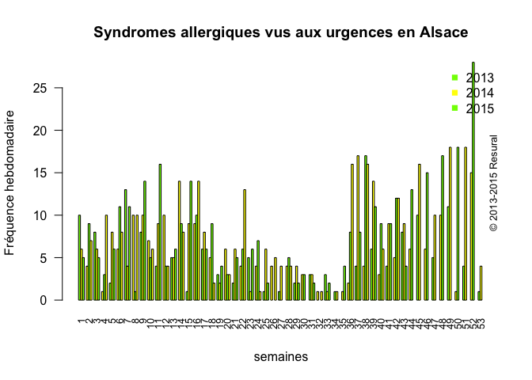

```r
# par semaine
b <- tapply(as.Date(allergie$ENTREE),list(year(as.Date(allergie$ENTREE)), week(as.Date(allergie$ENTREE))), length )
cols <- c("chartreuse", "yellow")
barplot(b, beside = TRUE, main = "Syndromes allergiques vus aux urgences en Alsace", ylab = "Fréquence hebdomadaire", las = 2, cex.names = 0.8, col = cols, xlab = "semaines")
legend("topright", legend = rownames(a), col = cols, pch = 15, bty = "n")
copyright()
```

# 8 Pathologies liées à la chaleur

- deshydratation: E86
- coup de caleur et insolation: T67.0
- syncope due à la chaleur: T67.1
- crampes dues à la chaleur`: T67.2
- épuisement du à la chaleur avec perte d’eau: T67.3
- épuisement du à la chaleur avec perte de sel: T67.4
- épuisement du à la chaleur: T67.5
- fatigue transitoire due à la chaleur: T67.6

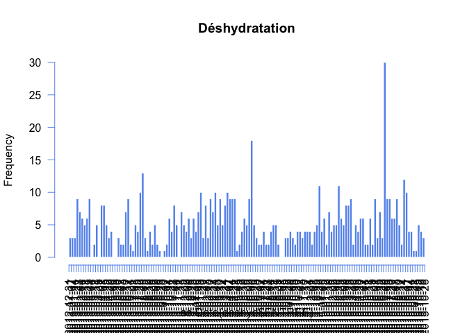

```r
# 2014-2015
deshyd <-dpr[substr(dpr$DP,1,3)=="E86", ]
chaleur <-dpr[substr(dpr$DP,1,3)=="T67", ]
hist(as.Date(deshyd$ENTREE), start.on.monday = TRUE, breaks = "weeks", freq = TRUE, format = "", las = 2, border = "white", col = "cornflowerblue", main = "Déshydratation", cex = 0.6)
```

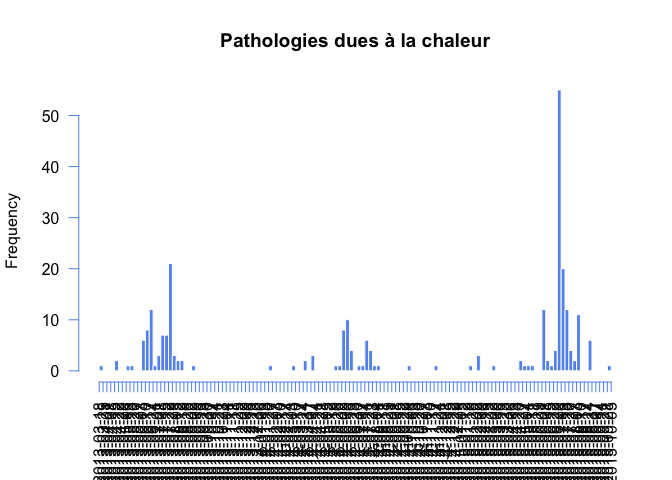

```r
hist(as.Date(chaleur$ENTREE), start.on.monday = TRUE, breaks = "weeks", freq = TRUE, format = "", las = 2, border = "white", col = "cornflowerblue", main = "Pathologies dues à la chaleur", cex = 0.6)
```

# 9 Maladies à déclaration obligatoire

```r
# pattern

typhoide <- "[A][0][1]|[A][0][1][01234]"
```